# StroopProject

David Vartanian

5 September 2017

# Stroop - Perceptual Phenomenon

### by David Vartanian

- Link to the test: https://faculty.washington.edu/chudler/java/ready.html
- Link to t-table: https://s3.amazonaws.com/udacity-hosted-downloads/t-table.jpg

### 1. What is our independent variable? What is our dependent variable?

Independent variable (predictor): Congruent and Incongruent.

Dependent variable (outcome): Time spent by people to complete each test.

### 2. What is an appropriate set of hypotheses for this task? What kind of statistical test do you expect to perform? Justify your choices.

We are trying to test whether the difference in time between taking the two tests is significant. I will use $\mu_c$ to represent the infered population mean for the *Congruent* test, and $\mu_i$ for the *Incongruent* test.

$$H_0: \mu_c = \mu_i$$

The *null* hypothesis expects that the difference between $\mu_c$ and $\mu_i$ will not statistically significant.

$$H_a: \mu_c < \mu_i$$

On the other hand, the *alternative* hypothesis expects that $\mu_c$ will be significantly less than $\mu_i$.

### 3. Report some descriptive statistics regarding this dataset. Include at least one measure of central tendency and at least one measure of variability.

```r
# Count:
nrow(data)
```

```
## [1] 24
```

```r
# Min, max, mean:
summary(data)
```

```
##    Congruent      Incongruent
##  Min.   : 8.63   Min.   :15.69
##  1st Qu.:11.90   1st Qu.:18.72
##  Median :14.36   Median :21.02
##  Mean   :14.05   Mean   :22.02
##  3rd Qu.:16.20   3rd Qu.:24.05
##  Max.   :22.33   Max.   :35.26
```

```r
# Variance:
var(data)
```

```
##             Congruent Incongruent
## Congruent   12.669029    6.007123
## Incongruent  6.007123   23.011757
```

```r
# Congruent Standard Deviation
sd(data$Congruent)
```

```
## [1] 3.559358
```

```r
# Incongruent Standard Deviation
sd(data$Incongruent)
```

```
## [1] 4.797057
```

### 4. Provide one or two visualizations that show the distribution of the sample data. Write one or two sentences noting what you observe about the plot or plots.

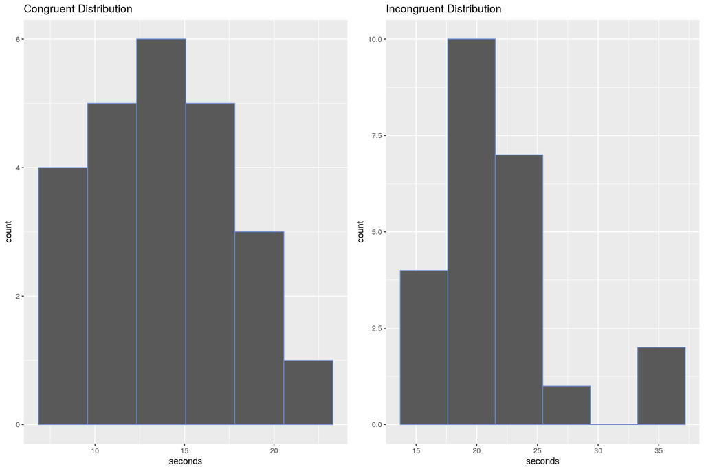

Ranges in X axis are actually different in both histograms. As you can see, most of observations are located around 15 seconds in the Congruent histogram, while in the Incongruent histogram, most of observations are located between 20 and 25 seconds.

### 6. Optional: What do you think is responsible for the effects observed? Can you think of an alternative or similar task that would result in a similar effect? Some research about the problem will be helpful for thinking about these two questions!

The effect is caused by a conflict between what for the brain is easier (words) and what we need to pay attention to (colours).

Extracted from the Stroop Effect website:

> The words themselves have a strong influence over your ability to say the color. The interference between the different information (what the words say and the color of the words) your brain receives causes a problem. There are two theories that may explain the Stroop effect:

> Speed of Processing Theory: the interference occurs because words are read faster than colors are named. Selective Attention Theory: the interference occurs because naming colors requires more attention than reading words.

> More experiments to try:
> - Turn the words upside down or rotate them 90 degrees.
> - Turn the words “inside out.”
> - Use non-color words such as “dog” or “house.”
> - Use nonsense words such as “kiw” or “thoz.”
> - Compare long words to short words.
> - Use emotional words such as “sad” or “happy” or “depressed” or “angry.”
> - Color only half of the word or color only the first and last letter of each word.